# Prediction Assignment Writeup

Mark Brown

September 13, 2018

# Assignment Background

Using devices such as Jawbone Up, Nike FuelBand, and Fitbit it is now possible to collect a large amount of data about personal activity relatively inexpensively. These type of devices are part of the quantified self movement – a group of enthusiasts who take measurements about themselves regularly to improve their health, to find patterns in their behavior, or because they are tech geeks. One thing that people regularly do is quantify how much of a particular activity they do, but they rarely quantify how well they do it. In this project, your goal will be to use data from accelerometers on the belt, forearm, arm, and dumbell of 6 participants. They were asked to perform barbell lifts correctly and incorrectly in 5 different ways. More information is available from the website here: http://web.archive.org/web/20161224072740/http:/groupware.les.inf.puc-rio.br/har (see the section on the Weight Lifting Exercise Dataset).

# Data

The training data for this project are available here:

https://d396qusza40orc.cloudfront.net/predmachlearn/pml-training.csv

The test data are available here:

https://d396qusza40orc.cloudfront.net/predmachlearn/pml-testing.csv

The data for this project come from this source: http://web.archive.org/web/20161224072740/http:/groupware.les.inf.puc-rio.br/har. Thank you for providing the data for this project.

# Now for the analysis

## R Packages that we are using

```r
library(caret)
library(rpart)
library(tidyverse)
library(randomForest)
```

```r
library(rpart.plot)
library(corrplot)
```

## Downloading the data and cleaning the data

```r
train <- "https://d396qusza40orc.cloudfront.net/predmachlearn/pml-training.csv"
test <- "https://d396qusza40orc.cloudfront.net/predmachlearn/pml-testing.csv"

training <- read.csv(url(train), na.strings = c("NA", "", "#DIV0!"))
testing <- read.csv(url(test), na.strings = c("NA", "", "#DIV0!"))

training<-training[,colSums(is.na(training)) == 0]
testing <-testing[,colSums(is.na(testing)) == 0]
```

## maing sure the data is the same

```r
head(training)
```

```
##   X user_name raw_timestamp_part_1 raw_timestamp_part_2   cvtd_timestamp
## 1 1  carlitos           1323084231               788290 05/12/2011 11:23
## 2 2  carlitos           1323084231               808298 05/12/2011 11:23
## 3 3  carlitos           1323084231               820366 05/12/2011 11:23
## 4 4  carlitos           1323084232               120339 05/12/2011 11:23
## 5 5  carlitos           1323084232               196328 05/12/2011 11:23
## 6 6  carlitos           1323084232               304277 05/12/2011 11:23
##   new_window num_window roll_belt pitch_belt yaw_belt total_accel_belt
## 1         no         11      1.41       8.07    -94.4                3
## 2         no         11      1.41       8.07    -94.4                3
## 3         no         11      1.42       8.07    -94.4                3
## 4         no         12      1.48       8.05    -94.4                3
## 5         no         12      1.48       8.07    -94.4                3
## 6         no         12      1.45       8.06    -94.4                3
##   gyros_belt_x gyros_belt_y gyros_belt_z accel_belt_x accel_belt_y
```

[output cut: 76 more lines]

```r
head(testing)
```

```
##   X user_name raw_timestamp_part_1 raw_timestamp_part_2   cvtd_timestamp
## 1 1     pedro           1323095002               868349 05/12/2011 14:23
## 2 2    jeremy           1322673067               778725 30/11/2011 17:11
## 3 3    jeremy           1322673075               342967 30/11/2011 17:11
## 4 4    adelmo           1322832789               560311 02/12/2011 13:33
## 5 5    eurico           1322489635               814776 28/11/2011 14:13
## 6 6    jeremy           1322673149               510661 30/11/2011 17:12
##   new_window num_window roll_belt pitch_belt yaw_belt total_accel_belt
## 1         no         74    123.00      27.00    -4.75               20
## 2         no        431      1.02       4.87   -88.90                4
## 3         no        439      0.87       1.82   -88.50                5
## 4         no        194    125.00     -41.60   162.00               17
## 5         no        235      1.35       3.33   -88.60                3
## 6         no        504     -5.92       1.59   -87.70                4
##   gyros_belt_x gyros_belt_y gyros_belt_z accel_belt_x accel_belt_y
```

[output cut: 76 more lines]

```r
str(training)
```

```
## 'data.frame':    19622 obs. of  60 variables:
##  $ X                   : int  1 2 3 4 5 6 7 8 9 10 ...
##  $ user_name           : Factor w/ 6 levels "adelmo","carlitos",..: 2 2 2 2 2 2 2 2 2 2 ...
##  $ raw_timestamp_part_1: int  1323084231 1323084231 1323084231 1323084232 1323084232 1323084232 1323084232 1323084232 1323084232 1323084232 ...
##  $ raw_timestamp_part_2: int  788290 808298 820366 120339 196328 304277 368296 440390 484323 484434 ...
##  $ cvtd_timestamp      : Factor w/ 20 levels "02/12/2011 13:32",..: 9 9 9 9 9 9 9 9 9 9 ...
##  $ new_window          : Factor w/ 2 levels "no","yes": 1 1 1 1 1 1 1 1 1 1 ...
##  $ num_window          : int  11 11 11 12 12 12 12 12 12 12 ...
##  $ roll_belt           : num  1.41 1.41 1.42 1.48 1.48 1.45 1.42 1.42 1.43 1.45 ...
##  $ pitch_belt          : num  8.07 8.07 8.07 8.05 8.07 8.06 8.09 8.13 8.16 8.17 ...
##  $ yaw_belt            : num  -94.4 -94.4 -94.4 -94.4 -94.4 -94.4 -94.4 -94.4 -94.4 -94.4 ...
##  $ total_accel_belt    : int  3 3 3 3 3 3 3 3 3 3 ...
##  $ gyros_belt_x        : num  0 0.02 0 0.02 0.02 0.02 0.02 0.02 0.02 0.03 ...
##  $ gyros_belt_y        : num  0 0 0 0 0.02 0 0 0 0 0 ...
##  $ gyros_belt_z        : num  -0.02 -0.02 -0.02 -0.03 -0.02 -0.02 -0.02 -0.02 -0.02 0 ...
```

[output cut: 46 more lines]

```r
str(testing)
```

```
## 'data.frame':    20 obs. of  60 variables:
##  $ X                   : int  1 2 3 4 5 6 7 8 9 10 ...
##  $ user_name           : Factor w/ 6 levels "adelmo","carlitos",..: 6 5 5 1 4 5 5 5 2 3 ...
##  $ raw_timestamp_part_1: int  1323095002 1322673067 1322673075 1322832789 1322489635 1322673149 1322673128 1322673076 1323084240 1322837822 ...
##  $ raw_timestamp_part_2: int  868349 778725 342967 560311 814776 510661 766645 54671 916313 384285 ...
##  $ cvtd_timestamp      : Factor w/ 11 levels "02/12/2011 13:33",..: 5 10 10 1 6 11 11 10 3 2 ...
##  $ new_window          : Factor w/ 1 level "no": 1 1 1 1 1 1 1 1 1 1 ...
##  $ num_window          : int  74 431 439 194 235 504 485 440 323 664 ...
##  $ roll_belt           : num  123 1.02 0.87 125 1.35 -5.92 1.2 0.43 0.93 114 ...
##  $ pitch_belt          : num  27 4.87 1.82 -41.6 3.33 1.59 4.44 4.15 6.72 22.4 ...
##  $ yaw_belt            : num  -4.75 -88.9 -88.5 162 -88.6 -87.7 -87.3 -88.5 -93.7 -13.1 ...
##  $ total_accel_belt    : int  20 4 5 17 3 4 4 4 4 18 ...
##  $ gyros_belt_x        : num  -0.5 -0.06 0.05 0.11 0.03 0.1 -0.06 -0.18 0.1 0.14 ...
##  $ gyros_belt_y        : num  -0.02 -0.02 0.02 0.11 0.02 0.05 0 -0.02 0 0.11 ...
##  $ gyros_belt_z        : num  -0.46 -0.07 0.03 -0.16 0 -0.13 0 -0.03 -0.02 -0.16 ...
```

[output cut: 46 more lines]

## Dimension Reduction of the data

```r
training <- training[,8:dim(training)[2]]
testing <- testing[,8:dim(testing)[2]]
```

## Seperating data into traing test and valadation (60% 20% 20%)

```r
set.seed(1)
training1 <- createDataPartition(y = training$classe, p = 0.8, list = F)
validation1 <- training[training1,]
validation <- training[-training1,]
Training_data1 <- createDataPartition(y = validation1$classe, p = 0.75, list = F)
training_data2 <- validation1[Training_data1,]
testing_data <- validation1[-Training_data1,]
```

## Exploring

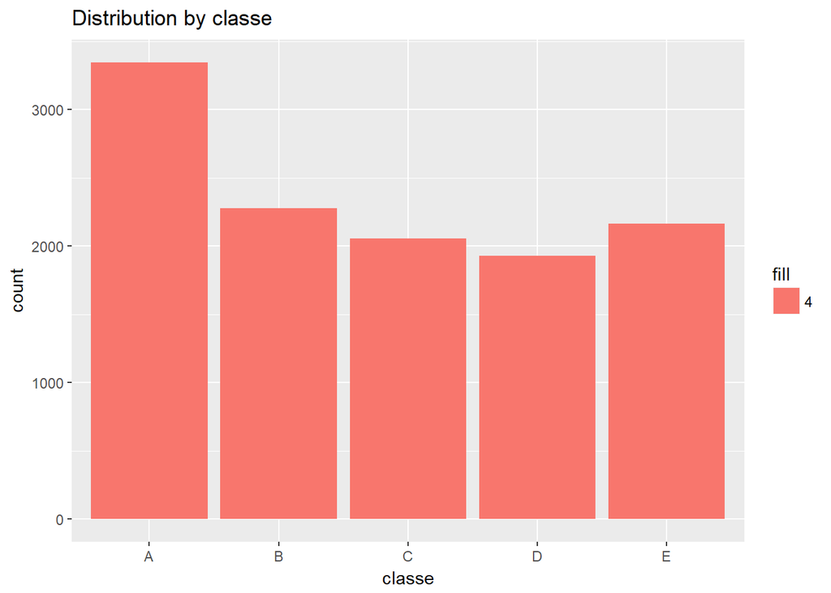

```r
qplot(classe, fill = "4", data=training_data2, main="Distribution by classe")
```

# Building Modls

## A Decision Tree Model

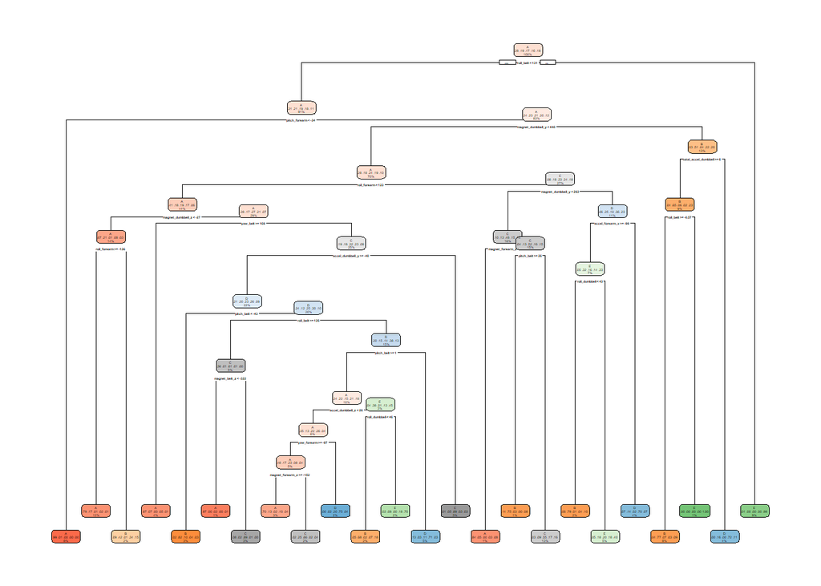

```r
model_tree <- rpart(classe ~ ., data=training_data2, method="class")
rpart.plot(model_tree)
```

```r
prediction_tree <- predict(model_tree, testing_data, type="class")
class_tree <- confusionMatrix(prediction_tree, testing_data$classe)
class_tree
```

```
## Confusion Matrix and Statistics
##
##           Reference
## Prediction   A   B   C   D   E
##          A 994 123   7  31  12
##          B  45 454  48  49  70
##          C  27  78 553  97 102
##          D  33  49  30 415  37
##          E  17  55  46  51 500
##
## Overall Statistics
##
##                Accuracy : 0.7433
##                  95% CI : (0.7293, 0.7569)
##     No Information Rate : 0.2845
##     P-Value [Acc > NIR] : < 2.2e-16
##
##                   Kappa : 0.6749
##  Mcnemar's Test P-Value : < 2.2e-16
##
## Statistics by Class:
##
##                      Class: A Class: B Class: C Class: D Class: E
## Sensitivity            0.8907   0.5982   0.8085   0.6454   0.6935
## Specificity            0.9384   0.9330   0.9061   0.9546   0.9472
## Pos Pred Value         0.8518   0.6817   0.6453   0.7358   0.7474
## Neg Pred Value         0.9557   0.9064   0.9573   0.9321   0.9321
## Prevalence             0.2845   0.1935   0.1744   0.1639   0.1838
## Detection Rate         0.2534   0.1157   0.1410   0.1058   0.1275
## Detection Prevalence   0.2975   0.1698   0.2185   0.1438   0.1705
## Balanced Accuracy      0.9145   0.7656   0.8573   0.8000   0.8204
```

## A Random Forest Model

```r
model_forest <- randomForest(classe ~ ., data=training_data2, method="class")
prediction_forest <- predict(model_forest, testing_data, type="class")
random_forest <- confusionMatrix(prediction_forest, testing_data$classe)
random_forest
```

```
## Confusion Matrix and Statistics
##
##           Reference
## Prediction    A    B    C    D    E
##          A 1114    6    0    0    0
##          B    2  748    5    0    0
##          C    0    5  679    5    0
##          D    0    0    0  638    2
##          E    0    0    0    0  719
##
## Overall Statistics
##
##                Accuracy : 0.9936
##                  95% CI : (0.9906, 0.9959)
##     No Information Rate : 0.2845
##     P-Value [Acc > NIR] : < 2.2e-16
##
##                   Kappa : 0.9919
##  Mcnemar's Test P-Value : NA
##
## Statistics by Class:
##
##                      Class: A Class: B Class: C Class: D Class: E
## Sensitivity            0.9982   0.9855   0.9927   0.9922   0.9972
## Specificity            0.9979   0.9978   0.9969   0.9994   1.0000
## Pos Pred Value         0.9946   0.9907   0.9855   0.9969   1.0000
## Neg Pred Value         0.9993   0.9965   0.9985   0.9985   0.9994
## Prevalence             0.2845   0.1935   0.1744   0.1639   0.1838
## Detection Rate         0.2840   0.1907   0.1731   0.1626   0.1833
## Detection Prevalence   0.2855   0.1925   0.1756   0.1631   0.1833
## Balanced Accuracy      0.9980   0.9916   0.9948   0.9958   0.9986
```

# Predictions

## Prediction Algorithms with confusion matrix

```r
prediction_tree <- predict(model_tree, testing_data, type="class")
tree <- confusionMatrix(prediction_tree, testing_data$classe)
tree
```

```
## Confusion Matrix and Statistics
##
##           Reference
## Prediction   A   B   C   D   E
##          A 994 123   7  31  12
##          B  45 454  48  49  70
##          C  27  78 553  97 102
##          D  33  49  30 415  37
##          E  17  55  46  51 500
##
## Overall Statistics
##
##                Accuracy : 0.7433
##                  95% CI : (0.7293, 0.7569)
##     No Information Rate : 0.2845
##     P-Value [Acc > NIR] : < 2.2e-16
##
##                   Kappa : 0.6749
##  Mcnemar's Test P-Value : < 2.2e-16
##
## Statistics by Class:
##
##                      Class: A Class: B Class: C Class: D Class: E
## Sensitivity            0.8907   0.5982   0.8085   0.6454   0.6935
## Specificity            0.9384   0.9330   0.9061   0.9546   0.9472
## Pos Pred Value         0.8518   0.6817   0.6453   0.7358   0.7474
## Neg Pred Value         0.9557   0.9064   0.9573   0.9321   0.9321
## Prevalence             0.2845   0.1935   0.1744   0.1639   0.1838
## Detection Rate         0.2534   0.1157   0.1410   0.1058   0.1275
## Detection Prevalence   0.2975   0.1698   0.2185   0.1438   0.1705
## Balanced Accuracy      0.9145   0.7656   0.8573   0.8000   0.8204
```

```r
prediction_forest <- predict(model_forest, newdata=testing_data)
forest<-confusionMatrix(prediction_forest, testing_data$classe)
forest
```

```
## Confusion Matrix and Statistics
##
##           Reference
## Prediction    A    B    C    D    E
##          A 1114    6    0    0    0
##          B    2  748    5    0    0
##          C    0    5  679    5    0
##          D    0    0    0  638    2
##          E    0    0    0    0  719
##
## Overall Statistics
##
##                Accuracy : 0.9936
##                  95% CI : (0.9906, 0.9959)
##     No Information Rate : 0.2845
##     P-Value [Acc > NIR] : < 2.2e-16
##
##                   Kappa : 0.9919
##  Mcnemar's Test P-Value : NA
##
## Statistics by Class:
##
##                      Class: A Class: B Class: C Class: D Class: E
## Sensitivity            0.9982   0.9855   0.9927   0.9922   0.9972
## Specificity            0.9979   0.9978   0.9969   0.9994   1.0000
## Pos Pred Value         0.9946   0.9907   0.9855   0.9969   1.0000
## Neg Pred Value         0.9993   0.9965   0.9985   0.9985   0.9994
## Prevalence             0.2845   0.1935   0.1744   0.1639   0.1838
## Detection Rate         0.2840   0.1907   0.1731   0.1626   0.1833
## Detection Prevalence   0.2855   0.1925   0.1756   0.1631   0.1833
## Balanced Accuracy      0.9980   0.9916   0.9948   0.9958   0.9986
```

## We can see that the Random Forest Model is better than the Tree Model in this case

# Conclusion

Using the data we built both a decision tree and random forest model and due to the characteristics of the data we have found that between these two models a random forest gives a signficant advanatage.